# Getting started with colorhcplot

Damiano Fantini

May 31, 2025

The `colorhcplot` package is a convenient tool for plotting colorful dendrograms where clusters, or sample groups, are highlighted by different colors. In order to generate a colorful dendrogram, `colorhcplot()` function requires 2 mandatory arguments: `hc` and `fac`:

- `hc` is the result of a `hclust()` call
- `fac` is a factor defining the grouping

The number of leaves of the dendrogram has to be identical to the length of fac (i.e., length(hc$labels) == length(fac) has to be TRUE). Also, the optional `colors` argument (if supplied) has to have a length of 1 (single color) or equal to the length of the levels of `fac`.

## Install

```r
install.packages("colorhcplot")
library(colorhcplot)
```

## Example 1: using the USArrests dataset

The first example is based on the USArrests dataset and compares the results of the standard `plot` method applied to a hclust-class object and the output of `colorhcplot()`. The use of simple arguments is illustrated.

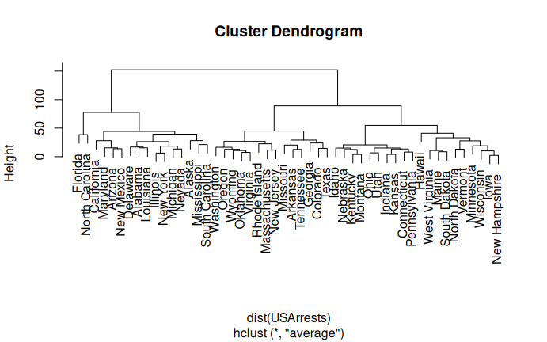

```r
data(USArrests)
hc <- hclust(dist(USArrests), "ave")
fac <- as.factor(c(rep("group 1", 10),
                   rep("group 2", 10),
                   rep("unknown", 30)))
plot(hc)
```

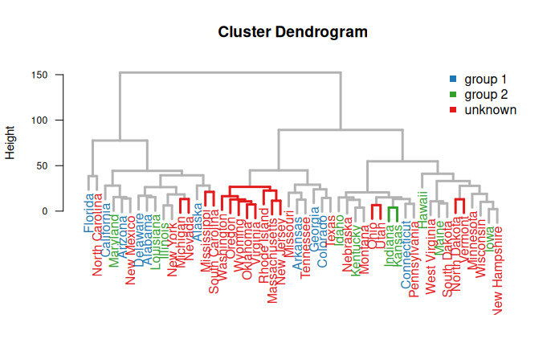

```r
colorhcplot(hc, fac)
```

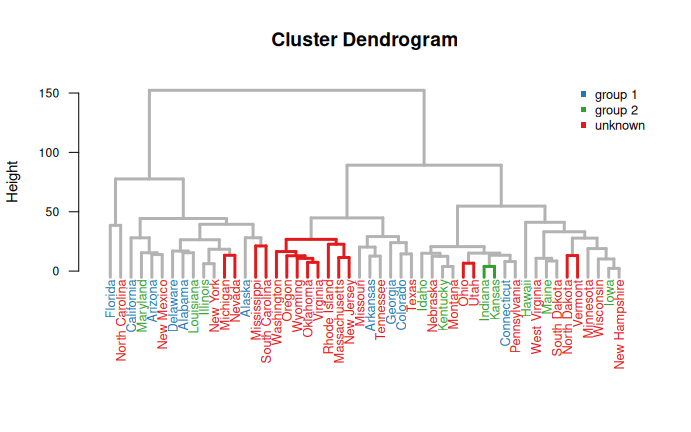

```r
colorhcplot(hc, fac, hang = -1, lab.cex = 0.8)
```

### Example 2: use the “ward.D2” algorithm and the UScitiesD dataset

The second example is based on the UScitiesD dataset. Here we show how to specify custom colors for the `colorhcplot()` call, using the `colors` argument.

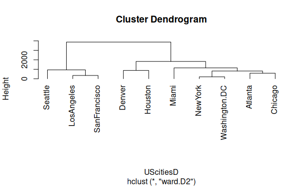

```r
data(UScitiesD)
hcity.D2 <- hclust(UScitiesD, "ward.D2")
fac.D2 <-as.factor(c(rep("group1", 3),
                     rep("group2", 7)))
plot(hcity.D2, hang=-1)
```

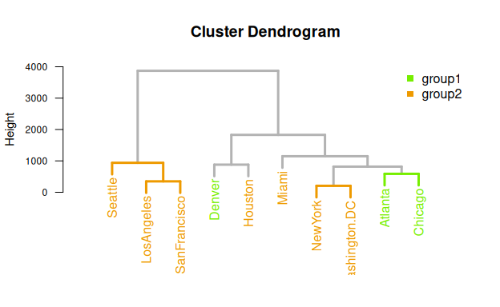

```r
colorhcplot(hcity.D2, fac.D2, color = c("chartreuse2", "orange2"))
```

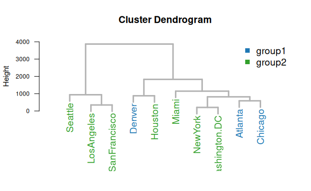

```r
colorhcplot(hcity.D2, fac.D2, color = "gray30", lab.cex = 1.2, lab.mar = 0.75)
```

## Example 3: use gene expression data

The third example is based on a sample gene expression dataset, which is included in the `colorhcplot` package. This illustrate how to use `colorhcplot()` for exploration and analysis of genomic data.

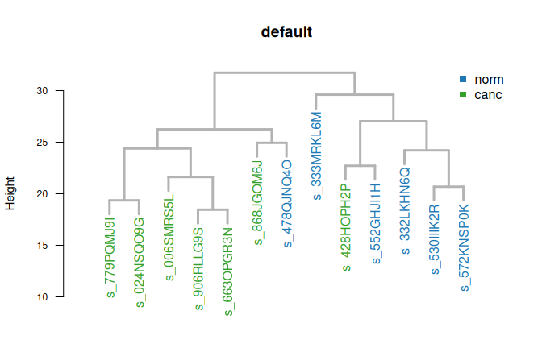

```r
data(geneData, package="colorhcplot")
exprs <- geneData$exprs
fac <- geneData$fac
hc <- hclust(dist(t(exprs)))
colorhcplot(hc, fac, main ="default", col = "gray10")
```

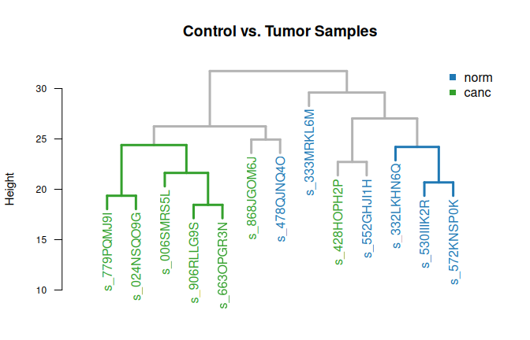

```r
colorhcplot(hc, fac, main="Control vs. Tumor Samples")
```